# Chapter 2

Nate

5/9/2020

```r
knitr::opts_chunk$set(comment = NA, message=F, warning=F)
library(faraway)
library(skimr)
library(magrittr)
library(tidyverse)
```

# 1.

```r
skim(teengamb)
```

Data summary

| Name | teengamb |
| --- | --- |
| Number of rows | 47 |
| Number of columns | 5 |
| _______________________ |  |
| Column type frequency: |  |
| numeric | 5 |
| ________________________ |  |
| Group variables | None |

**Variable type: numeric**

| skim_variable | n_missing | complete_rate | mean | sd | p0 | p25 | p50 | p75 | p100 | hist |
| --- | --- | --- | --- | --- | --- | --- | --- | --- | --- | --- |
| sex | 0 | 1 | 0.40 | 0.50 | 0.0 | 0.0 | 0.00 | 1.00 | 1 | ▇▁▁▁▆ |
| status | 0 | 1 | 45.23 | 17.26 | 18.0 | 28.0 | 43.00 | 61.50 | 75 | ▇▅▇▃▆ |
| income | 0 | 1 | 4.64 | 3.55 | 0.6 | 2.0 | 3.25 | 6.21 | 15 | ▇▃▂▂▁ |
| verbal | 0 | 1 | 6.66 | 1.86 | 1.0 | 6.0 | 7.00 | 8.00 | 10 | ▁▂▆▇▃ |
| gamble | 0 | 1 | 19.30 | 31.52 | 0.0 | 1.1 | 6.00 | 19.40 | 156 | ▇▁▁▁▁ |

```r
m <- lm(gamble ~ ., teengamb)
```

## a.

```r
sumary(m)
```

```
              Estimate Std. Error t value  Pr(>|t|)
(Intercept)  22.555651  17.196803  1.3116   0.19677
sex         -22.118330   8.211115 -2.6937   0.01011
status        0.052234   0.281112  0.1858   0.85349
income        4.961979   1.025392  4.8391 1.792e-05
verbal       -2.959493   2.172150 -1.3625   0.18031

n = 47, p = 5, Residual SE = 22.69034, R-Squared = 0.53
```

53%, reported by **the coefficient of determination**, aka ‘R-squared’.

## b.

```r
res <- resid(m)

which.max(res)
```

```
24
24
```

Case (row-number) 24 gambles more than the model expects.

## c.

```r
mean(res)
```

```
[1] -3.065293e-17
```

```r
median(res)
```

```
[1] -1.451392
```

The mean of the residuals should always be zero, we get this very-small (practically zero) value because of how computer math works. The median is a product of have only 47 cases, as more observations are collected the median will trend towards zero too.

## d.

```r
predict(m) %>% cor(res)
```

```
[1] 2.676157e-17
```

Again a practically zero value, indicating no correlation. This is means our linear model assumptions were not violated.

## e.

```r
teengamb$income %>% cor(res)
```

```
[1] -7.242382e-17
```

## f.

```r
?teengamb
# 0 = male
# gamb in pounds per year

sumary(m)
```

```
              Estimate Std. Error t value  Pr(>|t|)
(Intercept)  22.555651  17.196803  1.3116   0.19677
sex         -22.118330   8.211115 -2.6937   0.01011
status        0.052234   0.281112  0.1858   0.85349
income        4.961979   1.025392  4.8391 1.792e-05
verbal       -2.959493   2.172150 -1.3625   0.18031

n = 47, p = 5, Residual SE = 22.69034, R-Squared = 0.53
```

An average female would spend 22 pounds less per year that an average male, if we consider status, income and verbal as nuissance variables.

# 2.

```r
data("uswages")
?uswages
skim(uswages)
```

Data summary

| Name | uswages |
| --- | --- |
| Number of rows | 2000 |
| Number of columns | 10 |
| _______________________ |  |
| Column type frequency: |  |
| numeric | 10 |
| ________________________ |  |
| Group variables | None |

**Variable type: numeric**

| skim_variable | n_missing | complete_rate | mean | sd | p0 | p25 | p50 | p75 | p100 | hist |
| --- | --- | --- | --- | --- | --- | --- | --- | --- | --- | --- |
| wage | 0 | 1 | 608.12 | 459.83 | 50.39 | 308.64 | 522.32 | 783.48 | 7716.05 | ▇▁▁▁▁ |
| educ | 0 | 1 | 13.11 | 3.00 | 0.00 | 12.00 | 12.00 | 16.00 | 18.00 | ▁▁▁▇▅ |
| exper | 0 | 1 | 18.41 | 13.38 | -2.00 | 8.00 | 15.00 | 27.00 | 59.00 | ▇▇▅▃▁ |
| race | 0 | 1 | 0.08 | 0.27 | 0.00 | 0.00 | 0.00 | 0.00 | 1.00 | ▇▁▁▁▁ |
| smsa | 0 | 1 | 0.76 | 0.43 | 0.00 | 1.00 | 1.00 | 1.00 | 1.00 | ▂▁▁▁▇ |
| ne | 0 | 1 | 0.23 | 0.42 | 0.00 | 0.00 | 0.00 | 0.00 | 1.00 | ▇▁▁▁▂ |
| mw | 0 | 1 | 0.25 | 0.43 | 0.00 | 0.00 | 0.00 | 0.00 | 1.00 | ▇▁▁▁▂ |
| so | 0 | 1 | 0.31 | 0.46 | 0.00 | 0.00 | 0.00 | 1.00 | 1.00 | ▇▁▁▁▃ |
| we | 0 | 1 | 0.21 | 0.41 | 0.00 | 0.00 | 0.00 | 0.00 | 1.00 | ▇▁▁▁▂ |
| pt | 0 | 1 | 0.09 | 0.29 | 0.00 | 0.00 | 0.00 | 0.00 | 1.00 | ▇▁▁▁▁ |

```r
m <- lm(wage ~ educ + exper, uswages)
sumary(m)
```

```
             Estimate Std. Error t value  Pr(>|t|)
(Intercept) -242.7994    50.6816 -4.7907 1.785e-06
educ          51.1753     3.3419 15.3131 < 2.2e-16
exper          9.7748     0.7506 13.0227 < 2.2e-16

n = 2000, p = 3, Residual SE = 427.85384, R-Squared = 0.14
```

For every year of education the model estimates a $51 per week increase in wage. For every year of experience the model esimates only $10.

```r
update(m, log(wage, 10) ~ .) %>% sumary()
```

```
              Estimate Std. Error t value  Pr(>|t|)
(Intercept) 2.01960790 0.03402866  59.350 < 2.2e-16
educ        0.03930638 0.00224384  17.517 < 2.2e-16
exper       0.00785141 0.00050397  15.579 < 2.2e-16

n = 2000, p = 3, Residual SE = 0.28727, R-Squared = 0.17
```

# 3.

```r
x <- 1:20
y <- x + rnorm(20)

m <- lm(y ~ I(x^2))
sumary(m)
```

```
             Estimate Std. Error t value  Pr(>|t|)
(Intercept) 4.2297149  0.5175843   8.172 1.808e-07
I(x^2)      0.0434360  0.0027229  15.952 4.583e-12

n = 20, p = 2, Residual SE = 1.51804, R-Squared = 0.93
```

```r
direct_calc <- function(x, y, degree = 2) {
  x_mat <- model.matrix(~I(x^degree))
  solve(crossprod(x_mat), crossprod(x_mat, y))
}

direct_calc(x, y)
```

```
                  [,1]
(Intercept) 4.22971486
I(x^degree) 0.04343598
```

```r
map(set_names(3:7), possibly(~ direct_calc(x, y, degree = .), "Error"))
```

```
$`3`
                   [,1]
(Intercept) 5.822982230
I(x^degree) 0.002104216

$`4`
                    [,1]
(Intercept) 6.7384551336
I(x^degree) 0.0001030718

$`5`
                    [,1]
(Intercept) 7.343512e+00
I(x^degree) 5.058284e-06

$`6`
                    [,1]
(Intercept) 7.776159e+00
I(x^degree) 2.482373e-07

$`7`
[1] "Error"
```

# 4.

```r
data("prostate")
skim(prostate)
```

Data summary

| Name | prostate |
| --- | --- |
| Number of rows | 97 |
| Number of columns | 9 |
| _______________________ |  |
| Column type frequency: |  |
| numeric | 9 |
| ________________________ |  |
| Group variables | None |

**Variable type: numeric**

| skim_variable | n_missing | complete_rate | mean | sd | p0 | p25 | p50 | p75 | p100 | hist |
| --- | --- | --- | --- | --- | --- | --- | --- | --- | --- | --- |
| lcavol | 0 | 1 | 1.35 | 1.18 | -1.35 | 0.51 | 1.45 | 2.13 | 3.82 | ▃▅▇▆▃ |
| lweight | 0 | 1 | 3.65 | 0.50 | 2.37 | 3.38 | 3.62 | 3.88 | 6.11 | ▁▇▃▁▁ |
| age | 0 | 1 | 63.87 | 7.45 | 41.00 | 60.00 | 65.00 | 68.00 | 79.00 | ▁▁▅▇▂ |
| lbph | 0 | 1 | 0.10 | 1.45 | -1.39 | -1.39 | 0.30 | 1.56 | 2.33 | ▇▁▂▃▅ |
| svi | 0 | 1 | 0.22 | 0.41 | 0.00 | 0.00 | 0.00 | 0.00 | 1.00 | ▇▁▁▁▂ |
| lcp | 0 | 1 | -0.18 | 1.40 | -1.39 | -1.39 | -0.80 | 1.18 | 2.90 | ▇▂▂▂▂ |
| gleason | 0 | 1 | 6.75 | 0.72 | 6.00 | 6.00 | 7.00 | 7.00 | 9.00 | ▅▇▁▁▁ |
| pgg45 | 0 | 1 | 24.38 | 28.20 | 0.00 | 0.00 | 15.00 | 40.00 | 100.00 | ▇▂▂▁▁ |
| lpsa | 0 | 1 | 2.48 | 1.15 | -0.43 | 1.73 | 2.59 | 3.06 | 5.58 | ▁▅▇▃▁ |

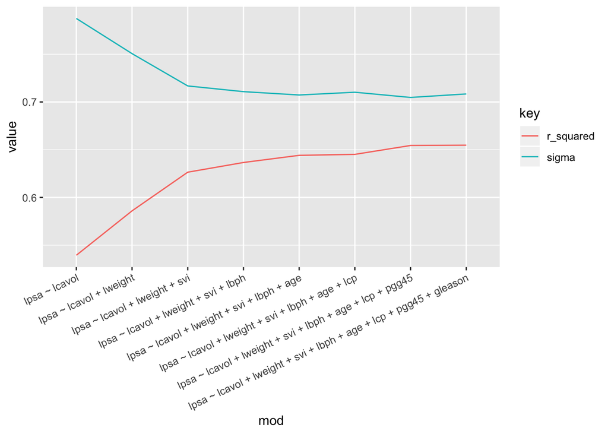

```r
m <- lm(lpsa ~ lcavol, prostate)

get_resid_error <- function(m) {
  s <- invisible(summary(m))
  data.frame(
    "mod" = formula(m) %>% deparse(),
    "sigma" = s$sigma,
    "r_squared" = s$r.squared
    )
}

resid_error_dat <- get_resid_error(m)

predictors_to_add <- c("lweight", "svi", "lbph", "age", "lcp", "pgg45", "gleason")

for (p in predictors_to_add) {
  f <- formula(m) %>% deparse() %>% paste("+", p)
  m <- update(m, f)

  resid_error_dat <- bind_rows(resid_error_dat, get_resid_error(m))
}

resid_error_dat %>%
  pivot_longer(-mod, "key") %>%
  ggplot(aes(mod, value, color = key, group = key)) +
  geom_path() +
  theme(axis.text.x = element_text(angle= 25, hjust = 1))
```

As more predictors are added, the estimate of population variance decreases and the coefficient of determinaiton (ammount of variance explained by the model) increases. Unadjuted R-squared will always increase as predictors are added to the model, the [adjusted R-squared](https://en.wikipedia.org/wiki/Coefficient_of_determination#Adjusted_R2) adds a penalty for n-predictors to compensate for that.

Note the rapid improvment in fit up to the model `lpsa ~ lcavol + lweight + svi`, perhaps that’s a good place to stop adding more predictors.

# 5.

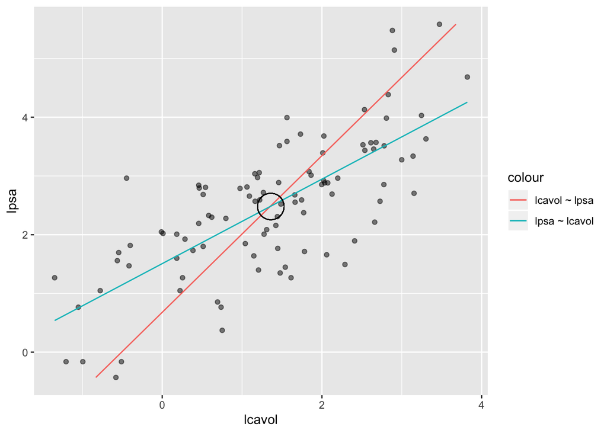

```r
m <- lm(lcavol ~ lpsa, prostate)
m2 <- lm(lpsa ~ lcavol, prostate)

ggplot(prostate, aes(lcavol, lpsa)) +
  geom_point(alpha = .5) +
  geom_line(aes(x = predict(m), color = "lcavol ~ lpsa")) +
  geom_line(aes(y = predict(m2), color = "lpsa ~ lcavol")) +
  geom_point(aes(y = 2.48, x = 1.36), shape = 1, size = 10)
```

Algebra not showm but you can calculate the intesection if you solve for either `lcavol` or `lpsa` in the system of equations represented by the model coefficients.

# 6.

```r
data("cheddar")
skim(cheddar)
```

Data summary

| Name | cheddar |
| --- | --- |
| Number of rows | 30 |
| Number of columns | 4 |
| _______________________ |  |
| Column type frequency: |  |
| numeric | 4 |
| ________________________ |  |
| Group variables | None |

**Variable type: numeric**

| skim_variable | n_missing | complete_rate | mean | sd | p0 | p25 | p50 | p75 | p100 | hist |
| --- | --- | --- | --- | --- | --- | --- | --- | --- | --- | --- |
| taste | 0 | 1 | 24.53 | 16.26 | 0.70 | 13.55 | 20.95 | 36.70 | 57.20 | ▅▇▃▃▃ |
| Acetic | 0 | 1 | 5.50 | 0.57 | 4.48 | 5.24 | 5.42 | 5.88 | 6.46 | ▆▆▇▇▇ |
| H2S | 0 | 1 | 5.94 | 2.13 | 3.00 | 3.98 | 5.33 | 7.57 | 10.20 | ▇▆▅▅▃ |
| Lactic | 0 | 1 | 1.44 | 0.30 | 0.86 | 1.25 | 1.45 | 1.67 | 2.01 | ▃▇▅▅▅ |

## a.

```r
m <- lm(taste ~ ., cheddar)
sumary(m)
```

```
             Estimate Std. Error t value Pr(>|t|)
(Intercept) -28.87677   19.73542 -1.4632 0.155399
Acetic        0.32774    4.45976  0.0735 0.941980
H2S           3.91184    1.24843  3.1334 0.004247
Lactic       19.67054    8.62905  2.2796 0.031079

n = 30, p = 4, Residual SE = 10.13071, R-Squared = 0.65
```

## b.

```r
cor(m$fitted.values, cheddar$taste)^2
```

```
[1] 0.6517747
```

R-Squared, the coeffecient of determination or percentage of variance explained

## c.

```r
m2 <- update(m, . ~ -1 + .)
cor(m2$fitted.values, cheddar$taste)^2
```

```
[1] 0.6244075
```

## d.

```r
m_mat <- model.matrix(m)

qr_decomp <- qr(m_mat)

backsolve(
  qr.R(qr_decomp), # upper-right
  t(qr.Q(qr_decomp)) %*% cheddar$taste
)
```

```
            [,1]
[1,] -28.8767696
[2,]   0.3277413
[3,]   3.9118411
[4,]  19.6705434
```

# 7.

```r
data("wafer")
skim(wafer)
```

Data summary

| Name | wafer |
| --- | --- |
| Number of rows | 16 |
| Number of columns | 5 |
| _______________________ |  |
| Column type frequency: |  |
| factor | 4 |
| numeric | 1 |
| ________________________ |  |
| Group variables | None |

**Variable type: factor**

| skim_variable | n_missing | complete_rate | ordered | n_unique | top_counts |
| --- | --- | --- | --- | --- | --- |
| x1 | 0 | 1 | FALSE | 2 | -: 8, +: 8 |
| x2 | 0 | 1 | FALSE | 2 | -: 8, +: 8 |
| x3 | 0 | 1 | FALSE | 2 | -: 8, +: 8 |
| x4 | 0 | 1 | FALSE | 2 | -: 8, +: 8 |

**Variable type: numeric**

| skim_variable | n_missing | complete_rate | mean | sd | p0 | p25 | p50 | p75 | p100 | hist |
| --- | --- | --- | --- | --- | --- | --- | --- | --- | --- | --- |
| resist | 0 | 1 | 229.27 | 50.54 | 165.7 | 200.97 | 214.25 | 259.3 | 339.9 | ▅▇▃▂▁ |

```r
m <- lm(resist ~ ., wafer)
```

## a.

```r
x <- model.matrix(m)
x
```

```
   (Intercept) x1+ x2+ x3+ x4+
1            1   0   0   0   0
2            1   1   0   0   0
3            1   0   1   0   0
4            1   1   1   0   0
5            1   0   0   1   0
6            1   1   0   1   0
7            1   0   1   1   0
8            1   1   1   1   0
9            1   0   0   0   1
10           1   1   0   0   1
11           1   0   1   0   1
12           1   1   1   0   1
13           1   0   0   1   1
14           1   1   0   1   1
15           1   0   1   1   1
16           1   1   1   1   1
attr(,"assign")
[1] 0 1 2 3 4
attr(,"contrasts")
attr(,"contrasts")$x1
[1] "contr.treatment"

attr(,"contrasts")$x2
[1] "contr.treatment"

attr(,"contrasts")$x3
[1] "contr.treatment"

attr(,"contrasts")$x4
[1] "contr.treatment"
```

As dummy variables, 1s and 0s.

## b.

```r
cor(x)
```

```
            (Intercept) x1+ x2+ x3+ x4+
(Intercept)           1  NA  NA  NA  NA
x1+                  NA   1   0   0   0
x2+                  NA   0   1   0   0
x3+                  NA   0   0   1   0
x4+                  NA   0   0   0   1
```

The intercept is constant and has no variance, so `cor()` throws a `NA` back.

```r
sd(x[,1])
```

```
[1] 0
```

```r
cor(x[,1], x[,1])
```

```
[1] NA
```

## c.

```r
sumary(m)
```

```
            Estimate Std. Error t value  Pr(>|t|)
(Intercept)  236.781     14.769 16.0322 5.645e-09
x1+           25.762     13.210  1.9502 0.0770849
x2+          -69.887     13.210 -5.2906 0.0002561
x3+           43.587     13.210  3.2996 0.0070828
x4+          -14.488     13.210 -1.0967 0.2961929

n = 16, p = 5, Residual SE = 26.41970, R-Squared = 0.8
```

Resistivity will increase by 26 unknown units. The SI unit of resistivity are ohm-meter.[Wikipedia](https://en.wikipedia.org/wiki/Electrical_resistivity_and_conductivity)

## d.

```r
m2 <- update(m, . ~ . - x4)
sumary(m)
```

```
            Estimate Std. Error t value  Pr(>|t|)
(Intercept)  236.781     14.769 16.0322 5.645e-09
x1+           25.762     13.210  1.9502 0.0770849
x2+          -69.887     13.210 -5.2906 0.0002561
x3+           43.587     13.210  3.2996 0.0070828
x4+          -14.488     13.210 -1.0967 0.2961929

n = 16, p = 5, Residual SE = 26.41970, R-Squared = 0.8
```

```r
sumary(m2)
```

```
            Estimate Std. Error t value  Pr(>|t|)
(Intercept)  229.538     13.321 17.2312 7.883e-10
x1+           25.762     13.321  1.9340 0.0770472
x2+          -69.887     13.321 -5.2464 0.0002056
x3+           43.587     13.321  3.2721 0.0066773

n = 16, p = 4, Residual SE = 26.64201, R-Squared = 0.78
```

## e.

The corrlations matrix shows that none of the predictors are correlated, so removing `x4` has no impact on the value estimates for the remaining predictors.

# 8.

```r
data("truck")
skim(truck)
```

Data summary

| Name | truck |
| --- | --- |
| Number of rows | 48 |
| Number of columns | 6 |
| _______________________ |  |
| Column type frequency: |  |
| factor | 5 |
| numeric | 1 |
| ________________________ |  |
| Group variables | None |

**Variable type: factor**

| skim_variable | n_missing | complete_rate | ordered | n_unique | top_counts |
| --- | --- | --- | --- | --- | --- |
| B | 0 | 1 | FALSE | 2 | +: 24, -: 24 |
| C | 0 | 1 | FALSE | 2 | +: 24, -: 24 |
| D | 0 | 1 | FALSE | 2 | +: 24, -: 24 |
| E | 0 | 1 | FALSE | 2 | +: 24, -: 24 |
| O | 0 | 1 | FALSE | 2 | +: 24, -: 24 |

**Variable type: numeric**

| skim_variable | n_missing | complete_rate | mean | sd | p0 | p25 | p50 | p75 | p100 | hist |
| --- | --- | --- | --- | --- | --- | --- | --- | --- | --- | --- |
| height | 0 | 1 | 7.64 | 0.25 | 7.12 | 7.5 | 7.59 | 7.81 | 8.18 | ▃▅▇▅▂ |

```r
truck %<>% mutate_if(is.factor, ~ ifelse(. == "-", -1, 1))
```

## a.

```r
m <- lm(height ~ ., truck)
sumary(m)
```

```
             Estimate Std. Error  t value  Pr(>|t|)
(Intercept)  7.636042   0.022909 333.3160 < 2.2e-16
B            0.110625   0.022909   4.8288 1.852e-05
C           -0.088125   0.022909  -3.8467 0.0004005
D           -0.014375   0.022909  -0.6275 0.5337453
E            0.051875   0.022909   2.2644 0.0287751
O           -0.129792   0.022909  -5.6655 1.201e-06

n = 48, p = 6, Residual SE = 0.15872, R-Squared = 0.64
```

## b.

```r
m2 <- update(m, . ~ . -O)
sumary(m2)
```

```
             Estimate Std. Error  t value  Pr(>|t|)
(Intercept)  7.636042   0.030073 253.9154 < 2.2e-16
B            0.110625   0.030073   3.6785 0.0006483
C           -0.088125   0.030073  -2.9304 0.0054015
D           -0.014375   0.030073  -0.4780 0.6350709
E            0.051875   0.030073   1.7250 0.0917167

n = 48, p = 5, Residual SE = 0.20835, R-Squared = 0.37
```

The coefficients are identical, because there is no correlation between predictors, `cor(model.matrix(m))` shows us that.

## c.

```r
truck %<>%
  rowwise() %>%
  mutate(A = sum(B, C, D, O))

m3 <- update(m, . ~ . + A)
sumary(m3)
```

```
Coefficients: (1 not defined because of singularities)
             Estimate Std. Error  t value  Pr(>|t|)
(Intercept)  7.636042   0.022909 333.3160 < 2.2e-16
B            0.110625   0.022909   4.8288 1.852e-05
C           -0.088125   0.022909  -3.8467 0.0004005
D           -0.014375   0.022909  -0.6275 0.5337453
E            0.051875   0.022909   2.2644 0.0287751
O           -0.129792   0.022909  -5.6655 1.201e-06

n = 48, p = 6, Residual SE = 0.15872, R-Squared = 0.64
```

`A` is not present becuse it is a linear combination the other predictors. Because the model realizes it can’t identify all of the predictors it warns us and drops the last predictor listed in the formula, until the model becomes identifiable. In this case `A` gets cut, but `update(m, . ~ A + .) %>% sumary()` would drop `O`.

## d.

```r
x <- model.matrix(m3)
solve(t(x) %*% x)
```

```
Error in solve.default(t(x) %*% x): Lapack routine dgesv: system is exactly singular: U[7,7] = 0
```

Singularities are a real problem.

## e.

```r
qr_decomp <- qr(x)
backsolve(
  qr.R(qr_decomp), # upper-right
  t(qr.Q(qr_decomp)) %*% truck$height
)
```

```
              [,1]
[1,]  7.636042e+00
[2,]  2.223706e+13
[3,]  2.223706e+13
[4,]  2.223706e+13
[5,]  4.759890e-02
[6,]  2.223706e+13
[7,] -2.223706e+13
```

No, most of the estimates are insanely large, which indicate a problem.

## f.

```r
qr.coef(qr_decomp, truck$height)
```

```
(Intercept)           B           C           D           E           O
  7.6360417   0.1106250  -0.0881250  -0.0143750   0.0518750  -0.1297917
          A
         NA
```